# assignment_11_12

Author

Jake Matullo

*Part 1*

**1. Load the airquality dataset in R. What does this dataset represent? Explore its structure using functions like str() and summary().**

```r
install.packages("airqualityES",  repos = "https://cran.rstudio.com")
library(tidymodels)
library(dplyr)

str(airquality)
```

```
'data.frame':   153 obs. of  6 variables:
 $ Ozone  : int  41 36 12 18 NA 28 23 19 8 NA ...
 $ Solar.R: int  190 118 149 313 NA NA 299 99 19 194 ...
 $ Wind   : num  7.4 8 12.6 11.5 14.3 14.9 8.6 13.8 20.1 8.6 ...
 $ Temp   : int  67 72 74 62 56 66 65 59 61 69 ...
 $ Month  : int  5 5 5 5 5 5 5 5 5 5 ...
 $ Day    : int  1 2 3 4 5 6 7 8 9 10 ...
```

```r
summary(airquality)
```

```
     Ozone           Solar.R           Wind             Temp
 Min.   :  1.00   Min.   :  7.0   Min.   : 1.700   Min.   :56.00
 1st Qu.: 18.00   1st Qu.:115.8   1st Qu.: 7.400   1st Qu.:72.00
 Median : 31.50   Median :205.0   Median : 9.700   Median :79.00
 Mean   : 42.13   Mean   :185.9   Mean   : 9.958   Mean   :77.88
 3rd Qu.: 63.25   3rd Qu.:258.8   3rd Qu.:11.500   3rd Qu.:85.00
 Max.   :168.00   Max.   :334.0   Max.   :20.700   Max.   :97.00
 NA's   :37       NA's   :7
     Month            Day
 Min.   :5.000   Min.   : 1.0
 1st Qu.:6.000   1st Qu.: 8.0
 Median :7.000   Median :16.0
 Mean   :6.993   Mean   :15.8
 3rd Qu.:8.000   3rd Qu.:23.0
 Max.   :9.000   Max.   :31.0
```

**2. Perform a Shapiro-Wilk normality test on the following variables: Ozone, Temp, Solar.R, and Wind.**

```r
shapiro.test(airquality$Ozone)
```

```
    Shapiro-Wilk normality test

data:  airquality$Ozone
W = 0.87867, p-value = 2.79e-08
```

```r
shapiro.test(airquality$Temp)
```

```
    Shapiro-Wilk normality test

data:  airquality$Temp
W = 0.97617, p-value = 0.009319
```

```r
shapiro.test(airquality$Solar.R)
```

```
    Shapiro-Wilk normality test

data:  airquality$Solar.R
W = 0.94183, p-value = 9.492e-06
```

```r
shapiro.test(airquality$Wind)
```

```
    Shapiro-Wilk normality test

data:  airquality$Wind
W = 0.98575, p-value = 0.1178
```

**3. What is the purpose of the Shapiro-Wilk test?**

The purpose of a Shapiro-Wilk test is to determine whether a set of data is normally distributed, as well as offering a p-value to determine significance.

**4. What are the null and alternative hypotheses for this test?**

The null hypothesis would be that the data is sourced from a normal distribution, while the alternative hypothesis would be that it isn’t and the data is skewed in some way. If the p-value is less than 0.05, then it is statistically significant, the null hypothesis is rejected, and the distribution ain’t normal.

**5. Interpret the p-values. Are these variables normally distributed?**

The only variable that is normally distributed in Wind. Everything else is skewed to some degree.

*Part 2*

```r
airquality <- airquality |>
  mutate(Season = case_when(
    Month %in% c(12, 1, 2) ~ "Winter",
    Month %in% c(3, 4, 5) ~ "Spring",
    Month %in% c(6, 7, 8) ~ "Summer",
    Month %in% c(9, 10, 11) ~ "Fall",
    TRUE ~ NA_character_
  ))
```

**7. Use table to figure out how many observations we have from each season.**

```r
table(airquality$Season)
```

```
  Fall Spring Summer
    30     31     92
```

**.8 Normalize the predictor variables (Temp, Solar.R, Wind, and Season) using a recipe.**

```r
library(recipes)

recipe_obj <- recipe(Temp ~ Solar.R + Wind + Season, data = airquality) %>%
  step_impute_mean(all_numeric_predictors()) %>%
  step_dummy(all_factor_predictors()) %>%
  step_normalize(all_numeric_predictors())
```

**9. What is the purpose of normalizing data?**

The purpose of normalizing data is to create data with a normal distribution that is then easier to work with.

**10. What function can be used to impute missing values with the mean?**

We use the step_impute_mean function in order to do that.

**11. prep and bake the data to generate a processed dataset.**

```r
prep_recipe <- prep(recipe_obj, training = airquality)

baked_recipe <- bake(prep_recipe, new_data = airquality)

summary(baked_recipe)
```

```
    Solar.R              Wind              Temp       Season_Spring
 Min.   :-2.03427   Min.   :-2.3439   Min.   :56.00   Min.   :-0.5024
 1st Qu.:-0.74960   1st Qu.:-0.7259   1st Qu.:72.00   1st Qu.:-0.5024
 Median : 0.09169   Median :-0.0731   Median :79.00   Median :-0.5024
 Mean   : 0.00000   Mean   : 0.0000   Mean   :77.88   Mean   : 0.0000
 3rd Qu.: 0.79656   3rd Qu.: 0.4378   3rd Qu.:85.00   3rd Qu.:-0.5024
 Max.   : 1.68332   Max.   : 3.0492   Max.   :97.00   Max.   : 1.9773
 Season_Summer
 Min.   :-1.2241
 1st Qu.:-1.2241
 Median : 0.8116
 Mean   : 0.0000
 3rd Qu.: 0.8116
 Max.   : 0.8116
```

**12. Why is it necessary to both prep() and bake() the recipe?**

It’s necessary because prepping the recipe processes and apples it to the data set in order to get normalized data, and baking the recipe applies transformations to the data set.

**13. Fit a linear model using Ozone as the response variable and all other variables as predictors. Remember that the . notation can we used to include all variables.**

```r
ozone_lm  <- lm(Ozone ~ Solar.R + Wind + Temp + Season + Month + Day, data = airquality)

summary(ozone_lm)
```

```
Call:
lm(formula = Ozone ~ Solar.R + Wind + Temp + Season + Month +
    Day, data = airquality)

Residuals:
    Min      1Q  Median      3Q     Max
-37.086 -13.015  -3.158   9.568  90.784

Coefficients:
               Estimate Std. Error t value Pr(>|t|)
(Intercept)  -139.64106   44.51438  -3.137  0.00223 **
Solar.R         0.05255    0.02342   2.244  0.02699 *
Wind           -3.12167    0.64846  -4.814 5.09e-06 ***
Temp            1.92275    0.34212   5.620 1.64e-07 ***
SeasonSpring   35.07123   16.70620   2.099  0.03823 *
SeasonSummer   15.77831    8.86584   1.780  0.07808 .
Month           4.70504    3.98921   1.179  0.24094
Day             0.23204    0.22986   1.009  0.31511
---
Signif. codes:  0 '***' 0.001 '**' 0.01 '*' 0.05 '.' 0.1 ' ' 1

Residual standard error: 20.62 on 103 degrees of freedom
  (42 observations deleted due to missingness)
Multiple R-squared:  0.6404,    Adjusted R-squared:  0.6159
F-statistic:  26.2 on 7 and 103 DF,  p-value: < 2.2e-16
```

**14. Interpret the model summary output (coefficients, R-squared, p-values) in plain language**

The relationship between ozone and month and day was insignificant, with the summer season being slightly more significant but still unremarkable. All other factors, and particularly wind and temperature, had significant effects on ozone levels. Their extreme t-values help further back this up. The variance in values in the data set mostly lines up with this relationship, though there are some unexplained values.

**15. Use broom::augment to supplement the normalized data.frame with the fitted values and residuals.**

```r
augment_lm <- broom::augment(ozone_lm)
```

```r
residuals_ozone_lm <- residuals(ozone_lm)
```

```r
library(ggplot2)
```

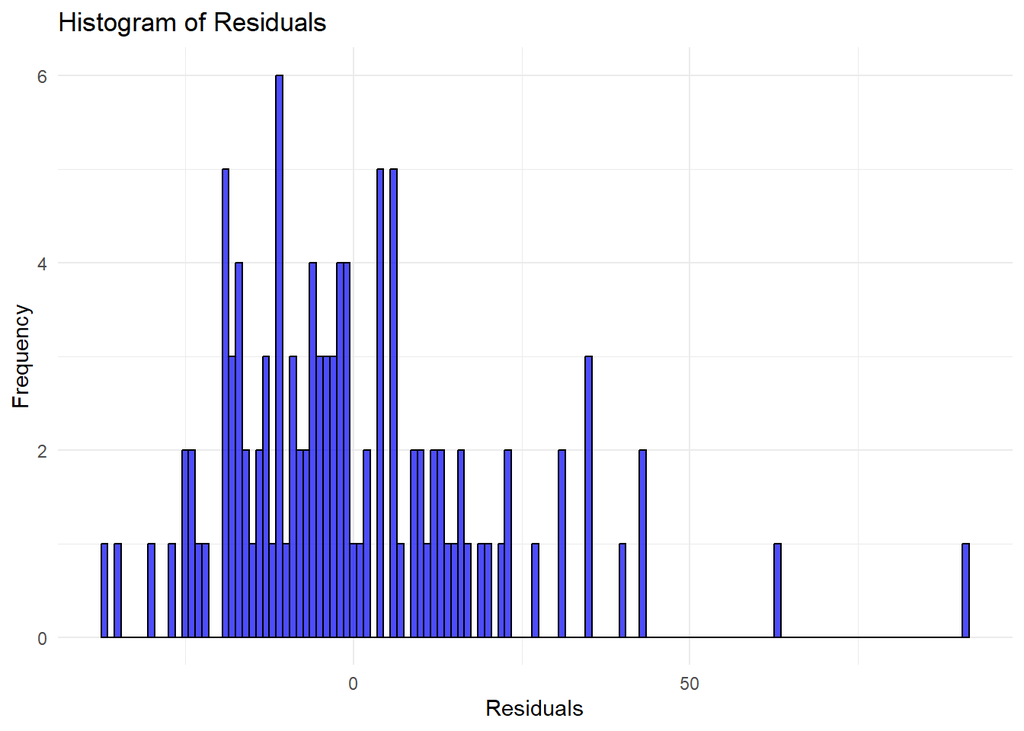

```r
p1 <- ggplot(data.frame(residuals_ozone_lm), aes(x = residuals_ozone_lm)) +
  geom_histogram(binwidth = 1, fill = "blue", color = "black", alpha = 0.7) +
  labs(title = "Histogram of Residuals", x = "Residuals", y = "Frequency") +
  theme_minimal()

print(p1)
```

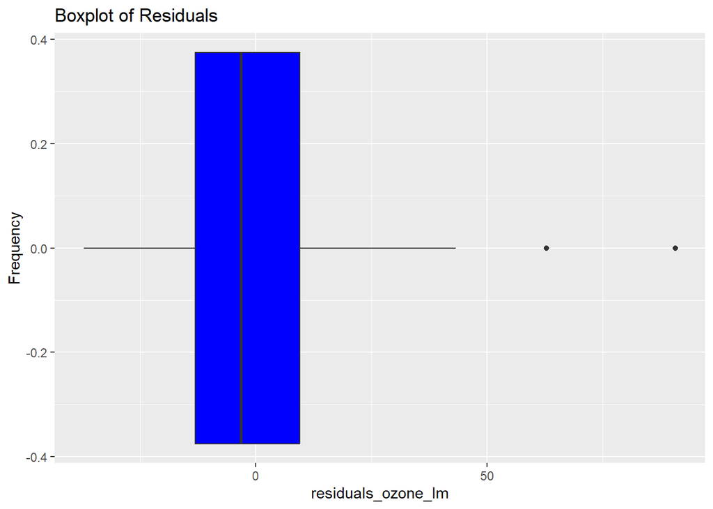

```r
p2 <- ggplot(data.frame(residuals_ozone_lm), aes(x = residuals_ozone_lm)) +
  geom_boxplot(fill = "blue") +
  ggtitle("Boxplot of Residuals") +
  ylab("Frequency")

print(p2)
```

**17. Use ggarange to plot this as one image and interpret what you see in them.**

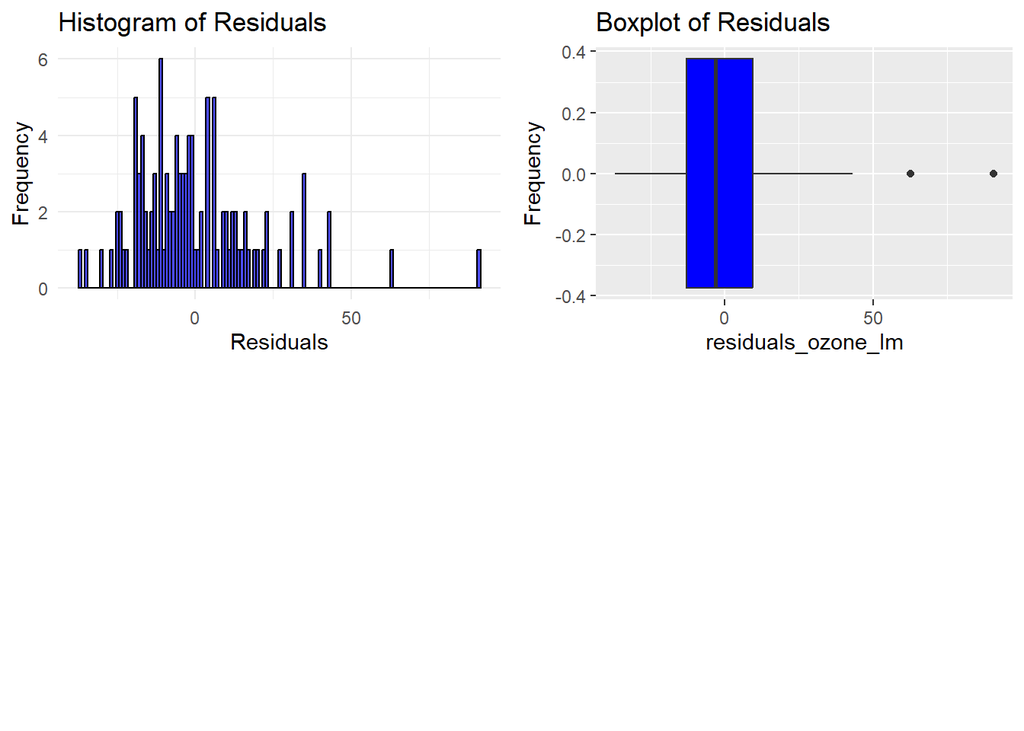

```r
library(ggpubr)
ggarrange(p1, p2, ncol = 2, nrow = 2)
```

**18. Create a scatter plot of actual vs. predicted values using ggpubr with the following setting:**

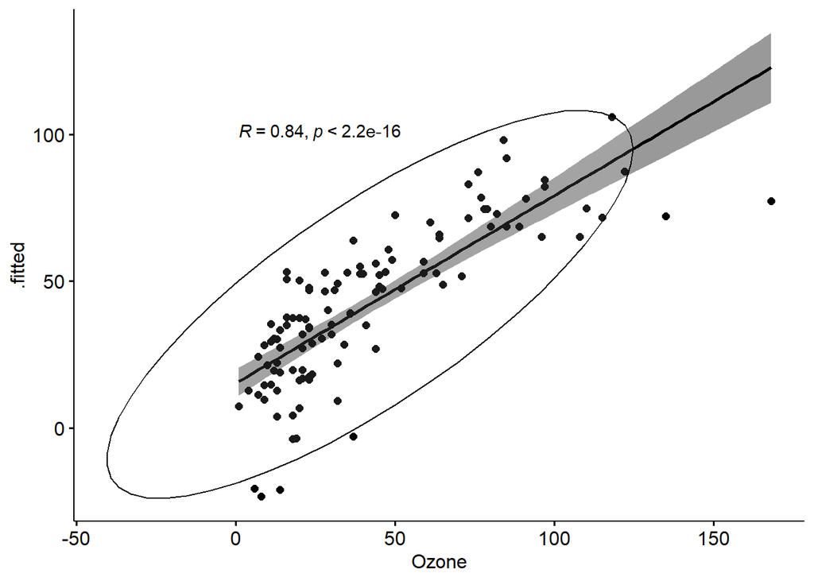

```r
library(ggpubr)

ggscatter(augment_lm, x = "Ozone", y = ".fitted",
          add = "reg.line", conf.int = TRUE,
          cor.coef = TRUE, cor.method = "spearman",
          ellipse = TRUE)
```

**19. How strong of a model do you think this is?**